# Single Image 3D reconstruction

by Michael Hafner, Moritz Langer, Aleksandar Radovic

## Responsibilities

| Classical Approach | Deep Learning Approach |
| --- | --- |
| Michael Hafner | Moritz Langer |
| Aleksandar Radovic |  |

## Introduction

To create 3D images out of 2D images stereovision is usually used. Therefore two images are needed to create a disparity map. With the help of the disparity map the 3D reconstruction can be developed. But what if you only have one camera and one image? Is it still possible to get a 3D image?

This question is been analyzed by Michael Hafner, Moritz Langer and Aleksandar Radovic in this project. A single 3D reconstruction can be done with the help of a neural network or without. Both approaches were developed in this project.

First the classical approach tries to get a 3D image with the help of the vanishing lines of the image. This approach has a lot of limitations which are shown below. To remove this limitations, the second part develops a neural network to achieve the goal of a single image 3D reconstruction.

## Classical Approach

The classic approach uses just vanishing lines and vanishing points to reconstruct the image.

- **Vanishing-Points:** Are points where the extended edge lines of an object´s dimension intersect.
- **Vanishing_Lines:** Are lines which connect vanishing points of all 3 dimensions.

This information can be used to extract information about the alignment (translation and rotation) of the given object in the image. This chapter explains how we developed our classic 3D reconstruction pipeline from camera calibration to the 3D object shown with Blender.

### Camera Calibration (done by Michael Hafner)

Since a camera ex- and intrinsics distort the image, in this project camera calibration was needed to remove those distortions. The used code for camera calibration got adapted directly from *OpenCV*. To determine the parameters of the camera the following steps are necessary:

1. Generate a checkerboard patter by using the *gen_pattern.py* file, provided in the Calibration folder.
   - *python gen_pattern.py -o chessboard.svg --rows 10 --columns 7 --type checkerboard --square_size 20*

   The amount of rows and columns declares the number of checker (white and black). The svg file than gets stored to the under *-o* declared path.
2. Print out the checkerboard pattern and stick it to a plain and stiff surface. Otherwise, possible curvatures distort the determined parameters of the algorithm.
3. Place the camera on its position where also the object gets photographed and take multiple images (angles) of the checkerboard. The more images, the more precise the results will become.
4. After that, execute the notebook *CamCalibration.ipynb*
   - The algorithm behind detects the edges where the black checker 'touch' each other.
   - With that and the information of the size of the checker in the real world it is possible to map the 3D real world checker in the 2D image plane and determine the camera parameters from the known dimensions of the calibration pattern.
5. This parameter then get stored in a numpy object/file to can be later used to undistort the image.

The following image shows the output of the calibration step, where the edges of the checker got detected by the algorithm.

```python
from IPython.display import Image
Image(url= "report-images/cal.png")
```

[figure not shown]

### Detect edges in image (done by Aleksandar Radovic)

The houghline algorithm makes it possible to detect lines in an image. As a parameter the edges are needed. This edges can be achieved by the open cv canny edge detection algorithm. By changing the treshhold of the canny algorithm it is possible to adjust the number of found edges. To get the optimum treshholds a sigma of 0.33 and the mean of the grayscale image was used.

However, the detected lines are still to much as you can see in the plot below

```python
imageWithEdges = undistorted_image
gray = cv2.cvtColor(imageWithEdges, cv2.COLOR_RGB2GRAY)
#find optimum parameters for canny (edge detection)
v = np.mean(gray)
sigma = 0.33
cannyTh1 = int(max(0, (1.0 - sigma) * v))
cannyTh2 = int(min(255, (1.0 + sigma) * v))
edges = cv2.Canny(gray, cannyTh1, cannyTh2)

lines = cv2.HoughLinesP(edges, 1, np.pi / 180, 30, maxLineGap=2500)
whiteImage = np.full((imageWithEdges.shape[0], imageWithEdges.shape[1], imageWithEdges.shape[2]), 255, dtype=np.uint8)

for line in lines:
    x1, y1, x2, y2 = line[0]
    cv2.line(imageWithEdges, (x1, y1), (x2, y2), (0, 255, 0), 1)
    cv2.line(whiteImage, (x1, y1), (x2, y2), (0, 255, 0), 1)
```

```python
from IPython.display import Image
Image(url= "report-images/houghlines.png")
```

[figure not shown]

A lot of different approaches were developed, but noone led to a good result. A lot of time was taken by searching for an method without an user interaction, but finally we had to the help include an user into the approach. There was no other way to get the exact edges of the image.

By adjusting the parameters of the canny and houghline algorithm only a few lines were detected. Each found line was then classified as correct or wrong by the user. If a line was correct, the user also inserts the coordinate of this specific line (x/y/z). If still lines are missing, a method was developed to let the user draw the lines as you can see in the image below.

```python
Image(url= "report-images/draw_lines.png")
```

[figure not shown]

In this plot the y coordinate lines are missing. By selecting to corners of the object, the user is able to draw a line manually.

Process:

- Drawing lines of the object in the image with the help of canny and houghline algorighm.
- Classifying each line by the user (correct/wrong).
- If line is correct, the user selects the coordinate (x/y/z) of it.
- Repeat first three steps until all detected houghlines were classified.
- If still lines are missing, the user can draw lines in the object by seleting two points.
- Specify the coordinate of the drawn line

```python
Image(url= "report-images/manuel_selected_lines.png")
```

[figure not shown]

As a result we got the edges of the object and a list with three lines for each coordinate.

```python
Image(url= "report-images/optimized_lines.png")
```

[figure not shown]

In the above plot the detected lines by the houghline algorithm are shown in the left image and in the right image the detected lines with the help of an user input.

It can be clearly seen, that the houghline algorithm alone is not enough to find the edges which are necessary to create a 3D reconstruction.

With this result the 3D reconstruction was explored with many different approaches, but none led to a 3D image of the book. The problem was that the vanishing points are outside the image, what made the distance calculation nearly impossible. Therefore, also for that step a user interaction was needed.

The 3D reconstruction approaches were explored by Michael Hafner and Aleksandar Radovic. None could find a solution without a user input. The final 3D reconstruction with the user interaction was developed by Michael Hafner.

### 3D Reconstruction (done by Michael Hafner)

After the extended lines of the object got determined it is possible now to calculate the intersections of those lines which provide the vanishing points.

With this information an algorithm from https://kusemanohar.wordpress.com/2014/03/18/3d-reconstruction-with-single-view/ got used to determine the projection matrix. With that matrix it should be possible to get the projection of each plane. As you can see in the following image, the algorithm failed.

```python
from IPython.display import Image
Image(url= "report-images/failed-transformation.png")
```

[figure not shown]

Since it was not possible to project the planes automatically using the above mentioned algorithm and finding or come up with another solution, a manual approach got used. With it first all side lengths of the object need to get measured to determine the ratios of the edge. After that the position (x-y values in the image) of every vertex got detected. The following code shows the transformation from the camera view to the plane view.

```python
trans = image.copy()
#source coordinates (edges in the image)
src = np.array([165, 293,
                413, 161,
                351, 423,
                195, 557, ]).reshape((4, 2))
#destination coordinates (rectangular shape of the corresponding plane, manually calculated from the lengths)
dst = np.array([165, 161,
                355, 161,
                355, 427,
                165, 427]).reshape((4, 2))
#using skimage’s transform module where ‘projective’ is our desired parameter
tform = transform.estimate_transform('projective', src, dst)
tf_img = transform.warp(trans, tform.inverse)

yz_plane = tf_img[161:427, 165:355]

plt.imshow(yz_plane)
plt.axis(False)
cv2.imwrite('object_images/yz_plane.png', 255 * yz_plane)
```

The source coordinates (src) got determined as previously mentioned of the vertices of each plane. To become now the plane view, the destination coordinates of those vertices need to be calculated. This was done by creating a rectangle using the vertex coordinates and the ratios of the objects edges. After that those parameter got used to transform the image and cut off the surrounding unnecessary and distorted pixel values.

```python
from IPython.display import Image
Image(url= "report-images/man-transformation.png")
```

[figure not shown]

This transformation can lead to distortions if there is another object on the corresponding plane. In the example below, there is an ear plug on top of the book cover. It can be seen, that the plug got wrapped by the transformation. So the transformation of object planes just works well on plain surfaces without other objects on top of it or other view restrictions (e.g. chimney on a roof)

```python
from IPython.display import Image
Image(url= "report-images/distortion-plug.png")
```

[figure not shown]

After the transformation, the numpy-stl library got used to create a stl file, which later can be used for a 3D suite e.g. Blender to process the created 3D object further (map the image planes to the object). The code bellow shows that first the vertices of the object need to be created. This was done by manually defining vertices corresponding to the edge length of the real object. After that, the vertices need to get connected to form a surface, this was done by using triangles. Therefore, the faces array contains the 3 numbers of the vertices which form the face. At last a 3D mesh got created and stored to the stl-file.

```python
# Define the 8 vertices of the cube, corresponding to the ratios of the real object
vertices = np.array([
    [-1, -1, -1],
    [+55, -1, -1],
    [+55, +190, -1],
    [-1, +190, -1],
    [-1, -1, +266],
    [+55, -1, +266],
    [+55, +190, +266],
    [-1, +190, +266]])
# Define the 12 triangles composing the cube
faces = np.array([
    [0, 3, 1],
    [1, 3, 2],
    [0, 4, 7],
    [0, 7, 3],
    [4, 5, 6],
    [4, 6, 7],
    [5, 1, 2],
    [5, 2, 6],
    [2, 3, 6],
    [3, 7, 6],
    [0, 1, 5],
    [0, 5, 4]])

# Create the mesh
cube = mesh.Mesh(np.zeros(faces.shape[0], dtype=mesh.Mesh.dtype))
for i, f in enumerate(faces):
    for j in range(3):
        cube.vectors[i][j] = vertices[f[j], :]

# Write the mesh to file "cube.stl"
cube.save('cube.stl')
```

This stl-file now can be opened with blender. To map the previous determined object planes to the corresponding images, the following steps are necessary:

1. Open the file in Blender

```python
from IPython.display import Image
Image(url= "report-images/blender-plain.png")
```

[figure not shown]

2. Create a material for each object plane
3. Select a face and assign it to the right material
4. Change the **Base Color** to the image of the surface

```python
from IPython.display import Image
Image(url= "report-images/blender-assign.png")
```

[figure not shown]

5. It is then possible to adjust the image (since the object ratios match to the image ratios, no further adjustment was needed)

```python
from IPython.display import Image
Image(url= "report-images/blender-mapped.png")
```

[figure not shown]

### Conclusion of the Classic Approach

In the recent approach it was found out that it is possible to create a 3D object using just a single input image. However, the process cannot be fully automated and the user needs to specify additional lines, the object ratios and angles manually. The image transformation to object planes also has limitations, as further objects in the scene can distort the image, and the view/angle is crucial for obtaining the desired result.

The success of the process is highly dependent on the complexity of the object being reconstructed. It was time-consuming and will definitely become more challenging for reconstructing complex objects. So the provided source code in the Classic-Approach/ folder just works for the given book image. For other objects the code or rather the points and ratios need to be recalculated and measured.

Furthermore, the presented approach is suitable for simple objects, more complex objects would require alternative techniques like ToF or structured light to enhance accuracy and performance.

## Deep Learning Approach for single image 3d reconstruction

*Moritz Langer*

### Introduction

The main problem with the classical approach is that we are constraint by simple shapes, and we can't have a lot of details. With the deep learning approach, we try to circumvent this by using a pretrained neural network. This gives us the possibility to create depth because the network has context so it can create a good estimation from a single image.

*Point Cloud*

The point cloud is a set of points in 3D space. Each point has a position and a colour. The position is the 3D coordinates of the point. With the point cloud we can create a 3D model of the object.

### Project Setup

The project is setup with conda. To run the code pytorch is needed. The code is tested with pytorch 1.13.1 on a macOS machine with an Apple M1 Max Chip. The model was trained on a ADM Vega 64 GPU running Ubuntu 20.04.

> Note: The code setup / dataset is used directly from https://github.com/lkhphuc/pytorch-3d-point-cloud-generation with small modifications. Due to a newer version of pytorch the code is not working out of the box. The code is modified to work with pytorch 1.13.1.

*Dataset*

The dataset is a sub selection of the ShapeNet dataset, only using the chairs. The Dataset consists of:

- Train/test split files (from Perspective Transformer Nets)
- Input RGB images (from Perspective Transformer Nets)
- Pre-rendered depth images for training
- Ground-truth point clouds of the test split (densified to 100K points)

The following code will demonstrate how the dataset is build:

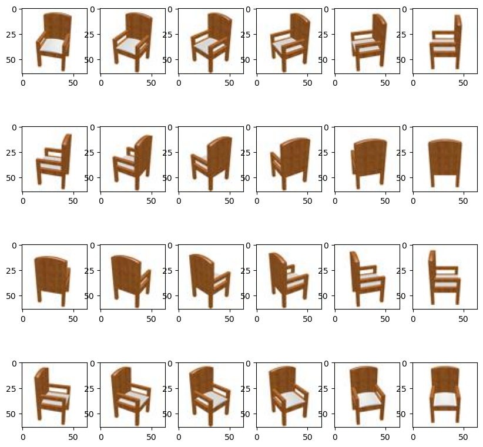

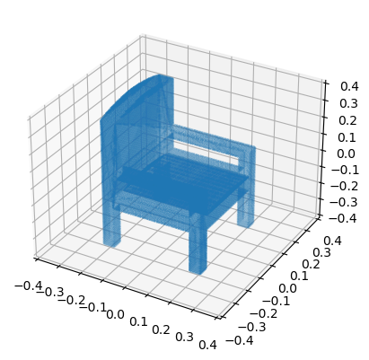

```python
import numpy as np
import matplotlib.pyplot as plt

import numpy as np
import matplotlib.pyplot as plt
import scipy.io as sio
#%matplotlib widget
#file = "1a6f615e8b1b5ae4dbbc9440457e303e"
file = "1a8bbf2994788e2743e99e0cae970928"
# open npy file
temp = np.load(f"deepLearning1/data/03001627_inputRGB/{file}.npy")
#plt.imshow(temp[2])
# subplot of 24 images
fig, axs = plt.subplots(4, 6, figsize=(10, 10))
for i in range(4):
    for j in range(6):
        axs[i, j].imshow(temp[i*6+j])
plt.show()
temp = sio.loadmat(f"deepLearning1/data/03001627_testGT/{file}.mat")
fig = plt.figure()
ax = fig.add_subplot(111, projection='3d')
ax.scatter(temp['Vd'][:,0], temp['Vd'][:,2], temp['Vd'][:,1], s=0.01)
ax.axes.set_xlim3d(left=-0.4, right=0.4)
ax.axes.set_ylim3d(bottom=-0.4, top=0.4)
ax.axes.set_zlim3d(bottom=-0.4, top=0.4)
plt.show()
```

*Running the code*

> These scripts were provided by the original author of the code. The code is modified to work with pytorch 1.13.1.

The following scripts gives examples for running the code.

- Pretraining the network: scripts/train-stg1.sh
- Fine-tuning with joint 2D optimization: scripts/train-stg2.sh
- Evaluating on the test set: scripts/evaluate.sh
- Computing the error metrics: scripts/evaluate_dist.sh

By default, one should run the code in the following order:

1. Pretrain the network: scripts/train-stg1.sh
   - This will save the best pretrained network to `models/ORIG_STG1_adam_trueWD_restart/best.pth`
   - as one can see in the logfile `UNI-AIS-ibcc/deepLearning1/logs/ORIG_STG1_adam_trueWD_restart.log` the network is trained for 1000 epochs
   - the best epoch is at the end 178
   - this is because the first sage only pretrains the network and the second stage fine-tunes the network
2. Fine-tune the network: scripts/train-stg2.sh
   - With the pretrained network we can now fine-tune the network
   - This will save the best pretrained network to `models/ORIG_STG2_adam_trueWD_restart/best.pth`
   - in this sage one epoch takes longer because the network is fine-tuned
   - therefor every tenth epoch is saved along with the best epoch
   - the current model is trained for about 1500 epochs as seen in the log files on an AMD Radeon Vega 64 GPU which takes about 5-6 days
3. Evaluate the network: scripts/evaluate.sh

If one now looks at the results of the model one can say that the model is trying to recreate the object, but the results are not very convincing. If you for example have a look at the ear chair: On the one hand the model is not able to create the legs but on the other hand the upper backrest with the 'ears' can be interpreted as the right direction.

This can mean 2 things:

1. The model is not trained enough
   - would need more epochs
   - this means more time / better hardware (GPU clustering) or newer hardware with special accelerators for deep learning
2. The model is not able to create the right shape
   - the chosen model is too simple
   - the model itself is not able to abstract the chair

The following code shows the input as well as the result of the model:

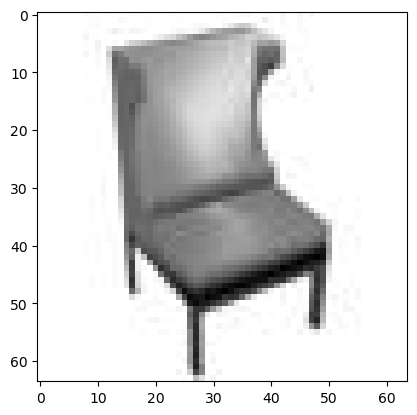

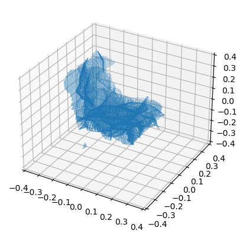

```python
#%matplotlib widget
import scipy.io as sio
imageNr = 21
#imageNr = 11 #Bad
# open mat file
#temp = sio.loadmat("deepLearning1/results/ORIG_STG2_sgd_trueWD_restart_cont1_orig/f46ccdbf92b738e64b3c42e318f3affc.mat") #Bad
#temp = sio.loadmat("deepLearning1/results/ORIG_STG2_sgd_trueWD_restart_cont1_orig/1a8bbf2994788e2743e99e0cae970928.mat") #Middle
temp = sio.loadmat("deepLearning1/results/ORIG_STG2_sgd_trueWD_restart_cont1_orig/f439a2db6341cd85f2b931201029bc76.mat") #OK
#temp = sio.loadmat("deepLearning1/results/ORIG_STG2_sgd_trueWD_restart_cont1_orig/a77b1abaa28588bb926350348c58b8b2.mat") #OK
fig = plt.figure()
plt.imshow(temp['image'][imageNr])
plt.show()
# plot 3d points
fig = plt.figure()
ax = fig.add_subplot(111, projection='3d')
ax.scatter(temp['pointcloud'][imageNr][0][:,0], temp['pointcloud'][imageNr][0][:,1], temp['pointcloud'][imageNr][0][:,2], s=0.1)
ax.axes.set_xlim3d(left=-0.4, right=0.4)
ax.axes.set_ylim3d(bottom=-0.4, top=0.4)
ax.axes.set_zlim3d(bottom=-0.4, top=0.4)
plt.show()
```

Furthermore, the output of the model is strongly influenced by the input. If the input is not good the output will also not be good. For example, if the input is a picture of a chair from the backside the model will only 'see' a square and will not be able to create the right shape.

*Model*

The model is defined in the PCGModel.py File. (PCG => Point Cloud Generation) The model consists of two elements:

1. The encoder
   - The encoder is a pretrained network which is used to extract features from the input image
   - The encoder is a pretrained VGG16 network
   - The pretrained network is used to extract features from the input image
   - The features are then used as input for the decoder
2. The decoder
   - The decoder is a network which is trained to create a point cloud from the features of the encoder

*Fusing Point clouds*

Since the model puts out only a 2d point cloud we need to fuse the point cloud to get a 3d point cloud. This can be done with pure geometry. This is implemented in the transform.py helper file.

## Summary

The topic of 3d reconstruction is a broad topic with mutliple approaches to a solution. The classical approach is very limited and can only create simple shapes. The deep learning approach is very promising, but the results are not very convincing. (At least for the limited training time in our case) The results are very dependent on the input. If the input is not good the output will also not be good. Furthermore, both approaches are limited in the application. For the classical approach the shapes are limited in term of their general form. With the deep learning approach, you are limited to the trained network. If you want to recreate houses for example and you train the network on chairs, then it would not be able to create the right shape. However, if you trained it on both the training would be more time intensive.